# ❤️ Heart Disease Prediction using Machine Learning

## Problem Statement

The objective of this project is to build a Machine Learning model that predicts whether a patient is likely to have heart disease based on clinical and medical attributes.

## Project Workflow

1. Import Libraries
2. Load Dataset
3. Dataset Overview
4. Data Cleaning
5. Exploratory Data Analysis (EDA)
6. Feature Engineering
7. Define Features and Target Variable
8. Train-Test Split
9. Feature Scaling
10. Model Building
- Logistic Regression
- Decision Tree
- Random Forest
11. Model Evaluation
- Logistic Regression Evaluation
- Decision Tree Evaluation
- Random Forest Evaluation
12. Hyperparameter Tuning
13. Feature Importance
14. Cross Validation
15. Model Comparison
16. Save and Load Best Model
17. New Patient Prediction
18. Conclusion

## 1. Import Required Libraries

```python
# Data Analysis
import pandas as pd
import numpy as np
# Data Visualization
import matplotlib.pyplot as plt
import seaborn as sns
# Data Preprocessing
from sklearn.model_selection import train_test_split,GridSearchCV,cross_val_score
from sklearn.preprocessing import StandardScaler
# Machine Learning Models
from sklearn.linear_model import LogisticRegression
from sklearn.tree import DecisionTreeClassifier
from sklearn.ensemble import RandomForestClassifier
# Model Evaluation
from sklearn.metrics import (accuracy_score,confusion_matrix,classification_report,roc_curve,roc_auc_score)
# Model Saving
import joblib
```

## 2. Load Dataset

```python
df=pd.read_csv("Heart disease dataset.csv")
```

## 3. Dataset Overview

```python
df.head()
```

|  | age | sex | cp | trestbps | chol | fbs | restecg | thalach | exang | oldpeak | slope | ca | thal | num |
| --- | --- | --- | --- | --- | --- | --- | --- | --- | --- | --- | --- | --- | --- | --- |
| 0 | 63 | 1 | 1 | 145 | 233 | 1 | 2 | 150 | 0 | 2.3 | 3 | 0.0 | 6.0 | 0 |
| 1 | 67 | 1 | 4 | 160 | 286 | 0 | 2 | 108 | 1 | 1.5 | 2 | 3.0 | 3.0 | 2 |
| 2 | 67 | 1 | 4 | 120 | 229 | 0 | 2 | 129 | 1 | 2.6 | 2 | 2.0 | 7.0 | 1 |
| 3 | 37 | 1 | 3 | 130 | 250 | 0 | 0 | 187 | 0 | 3.5 | 3 | 0.0 | 3.0 | 0 |
| 4 | 41 | 0 | 2 | 130 | 204 | 0 | 2 | 172 | 0 | 1.4 | 1 | 0.0 | 3.0 | 0 |

```python
df.shape
```

```
(303, 14)
```

```python
df.info()
```

```
<class 'pandas.core.frame.DataFrame'>
RangeIndex: 303 entries, 0 to 302
Data columns (total 14 columns):
 #   Column    Non-Null Count  Dtype
---  ------    --------------  -----
 0   age       303 non-null    int64
 1   sex       303 non-null    int64
 2   cp        303 non-null    int64
 3   trestbps  303 non-null    int64
 4   chol      303 non-null    int64
 5   fbs       303 non-null    int64
 6   restecg   303 non-null    int64
 7   thalach   303 non-null    int64
 8   exang     303 non-null    int64
 9   oldpeak   303 non-null    float64
 10  slope     303 non-null    int64
 11  ca        299 non-null    float64
 12  thal      301 non-null    float64
 13  num       303 non-null    int64
dtypes: float64(3), int64(11)
memory usage: 33.3 KB
```

```python
df.describe()
```

|  | age | sex | cp | trestbps | chol | fbs | restecg | thalach | exang | oldpeak | slope | ca | thal | num |
| --- | --- | --- | --- | --- | --- | --- | --- | --- | --- | --- | --- | --- | --- | --- |
| count | 303.000000 | 303.000000 | 303.000000 | 303.000000 | 303.000000 | 303.000000 | 303.000000 | 303.000000 | 303.000000 | 303.000000 | 303.000000 | 299.000000 | 301.000000 | 303.000000 |
| mean | 54.438944 | 0.679868 | 3.158416 | 131.689769 | 246.693069 | 0.148515 | 0.990099 | 149.607261 | 0.326733 | 1.039604 | 1.600660 | 0.672241 | 4.734219 | 0.937294 |
| std | 9.038662 | 0.467299 | 0.960126 | 17.599748 | 51.776918 | 0.356198 | 0.994971 | 22.875003 | 0.469794 | 1.161075 | 0.616226 | 0.937438 | 1.939706 | 1.228536 |
| min | 29.000000 | 0.000000 | 1.000000 | 94.000000 | 126.000000 | 0.000000 | 0.000000 | 71.000000 | 0.000000 | 0.000000 | 1.000000 | 0.000000 | 3.000000 | 0.000000 |
| 25% | 48.000000 | 0.000000 | 3.000000 | 120.000000 | 211.000000 | 0.000000 | 0.000000 | 133.500000 | 0.000000 | 0.000000 | 1.000000 | 0.000000 | 3.000000 | 0.000000 |
| 50% | 56.000000 | 1.000000 | 3.000000 | 130.000000 | 241.000000 | 0.000000 | 1.000000 | 153.000000 | 0.000000 | 0.800000 | 2.000000 | 0.000000 | 3.000000 | 0.000000 |
| 75% | 61.000000 | 1.000000 | 4.000000 | 140.000000 | 275.000000 | 0.000000 | 2.000000 | 166.000000 | 1.000000 | 1.600000 | 2.000000 | 1.000000 | 7.000000 | 2.000000 |
| max | 77.000000 | 1.000000 | 4.000000 | 200.000000 | 564.000000 | 1.000000 | 2.000000 | 202.000000 | 1.000000 | 6.200000 | 3.000000 | 3.000000 | 7.000000 | 4.000000 |

```python
df.columns
```

```
Index(['age', 'sex', 'cp', 'trestbps', 'chol', 'fbs', 'restecg', 'thalach',
       'exang', 'oldpeak', 'slope', 'ca', 'thal', 'num'],
      dtype='object')
```

## 4. Data Cleaning

```python
df.isnull().sum()
```

```
age         0
sex         0
cp          0
trestbps    0
chol        0
fbs         0
restecg     0
thalach     0
exang       0
oldpeak     0
slope       0
ca          4
thal        2
num         0
dtype: int64
```

```python
df["ca"]=df["ca"].fillna(df["ca"].median())
df["thal"]=df["thal"].fillna(df["thal"].median())
```

```python
df.isnull().sum()
```

```
age         0
sex         0
cp          0
trestbps    0
chol        0
fbs         0
restecg     0
thalach     0
exang       0
oldpeak     0
slope       0
ca          0
thal        0
num         0
dtype: int64
```

```python
df.duplicated().sum()
```

```
np.int64(0)
```

# 5. Exploratory Data Analysis (EDA)

## 5.1 Target Variable Distribution

```python
#Convert Target Variable into Binary Classes
df["num"]=df["num"].apply(lambda x: 0 if x==0 else 1)
```

```python
df["num"].value_counts()
```

```
num
0    164
1    139
Name: count, dtype: int64
```

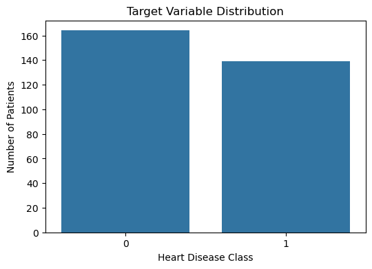

```python
plt.figure(figsize=(6,4))
sns.countplot(x="num",data=df)
plt.title("Target Variable Distribution")
plt.xlabel("Heart Disease Class")
plt.ylabel("Number of Patients")
plt.savefig("target_variable_distribution.png", dpi=300, bbox_inches="tight")
plt.show()
```

## 5.2 Age Distribution

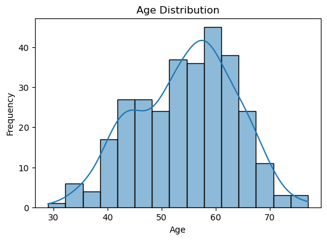

```python
plt.figure(figsize=(6,4))
sns.histplot(df["age"],bins=15,kde=True)
plt.title("Age Distribution")
plt.xlabel("Age")
plt.ylabel("Frequency")
plt.savefig("age_distribution.png", dpi=300, bbox_inches="tight")
plt.show()
```

## 5.3 Gender Distribution

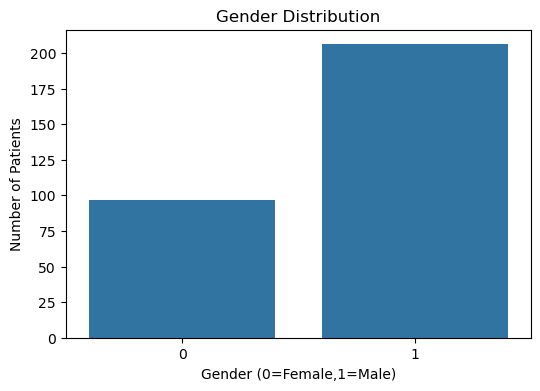

```python
plt.figure(figsize=(6,4))
sns.countplot(x="sex",data=df)
plt.title("Gender Distribution")
plt.xlabel("Gender (0=Female,1=Male)")
plt.ylabel("Number of Patients")
plt.show()
```

## 5.4 Chest Pain Type Distribution

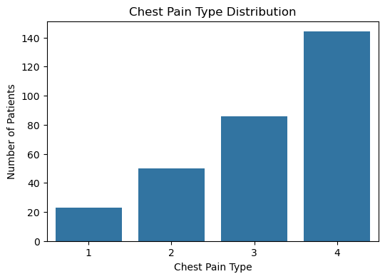

```python
plt.figure(figsize=(6,4))
sns.countplot(x="cp",data=df)
plt.title("Chest Pain Type Distribution")
plt.xlabel("Chest Pain Type")
plt.ylabel("Number of Patients")
plt.show()
```

## 5.5 Resting Blood Pressure Distribution

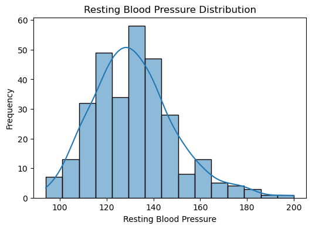

```python
plt.figure(figsize=(6,4))
sns.histplot(df["trestbps"],bins=15,kde=True)
plt.title("Resting Blood Pressure Distribution")
plt.xlabel("Resting Blood Pressure")
plt.ylabel("Frequency")
plt.show()
```

## 5.6 Cholesterol Distribution

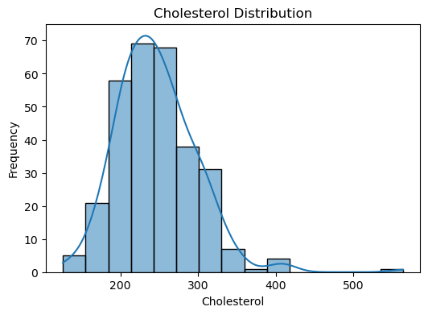

```python
plt.figure(figsize=(6,4))
sns.histplot(df["chol"],bins=15,kde=True)
plt.title("Cholesterol Distribution")
plt.xlabel("Cholesterol")
plt.ylabel("Frequency")
plt.show()
```

## 5.7 Maximum Heart Rate Distribution

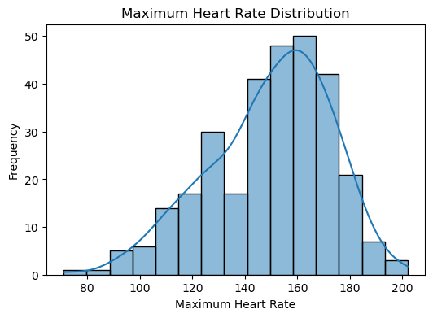

```python
plt.figure(figsize=(6,4))
sns.histplot(df["thalach"],bins=15,kde=True)
plt.title("Maximum Heart Rate Distribution")
plt.xlabel("Maximum Heart Rate")
plt.ylabel("Frequency")
plt.show()
```

## 5.8 ST Depression (Oldpeak) Distribution

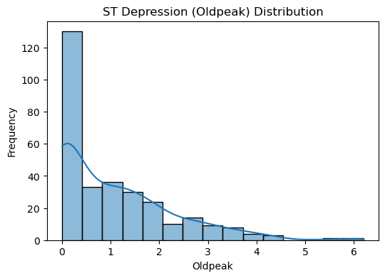

```python
plt.figure(figsize=(6,4))
sns.histplot(df["oldpeak"],bins=15,kde=True)
plt.title("ST Depression (Oldpeak) Distribution")
plt.xlabel("Oldpeak")
plt.ylabel("Frequency")
plt.show()
```

## 5.9 Correlation Analysis

```python
df.corr()
```

|  | age | sex | cp | trestbps | chol | fbs | restecg | thalach | exang | oldpeak | slope | ca | thal | num |
| --- | --- | --- | --- | --- | --- | --- | --- | --- | --- | --- | --- | --- | --- | --- |
| age | 1.000000 | -0.097542 | 0.104139 | 0.284946 | 0.208950 | 0.118530 | 0.148868 | -0.393806 | 0.091661 | 0.203805 | 0.161770 | 0.365323 | 0.128303 | 0.223120 |
| sex | -0.097542 | 1.000000 | 0.010084 | -0.064456 | -0.199915 | 0.047862 | 0.021647 | -0.048663 | 0.146201 | 0.102173 | 0.037533 | 0.086048 | 0.380581 | 0.276816 |
| cp | 0.104139 | 0.010084 | 1.000000 | -0.036077 | 0.072319 | -0.039975 | 0.067505 | -0.334422 | 0.384060 | 0.202277 | 0.152050 | 0.233117 | 0.262089 | 0.414446 |
| trestbps | 0.284946 | -0.064456 | -0.036077 | 1.000000 | 0.130120 | 0.175340 | 0.146560 | -0.045351 | 0.064762 | 0.189171 | 0.117382 | 0.097528 | 0.134424 | 0.150825 |
| chol | 0.208950 | -0.199915 | 0.072319 | 0.130120 | 1.000000 | 0.009841 | 0.171043 | -0.003432 | 0.061310 | 0.046564 | -0.004062 | 0.123726 | 0.018351 | 0.085164 |
| fbs | 0.118530 | 0.047862 | -0.039975 | 0.175340 | 0.009841 | 1.000000 | 0.069564 | -0.007854 | 0.025665 | 0.005747 | 0.059894 | 0.140764 | 0.064625 | 0.025264 |
| restecg | 0.148868 | 0.021647 | 0.067505 | 0.146560 | 0.171043 | 0.069564 | 1.000000 | -0.083389 | 0.084867 | 0.114133 | 0.133946 | 0.131749 | 0.024325 | 0.169202 |
| thalach | -0.393806 | -0.048663 | -0.334422 | -0.045351 | -0.003432 | -0.007854 | -0.083389 | 1.000000 | -0.378103 | -0.343085 | -0.385601 | -0.265699 | -0.274142 | -0.417167 |
| exang | 0.091661 | 0.146201 | 0.384060 | 0.064762 | 0.061310 | 0.025665 | 0.084867 | -0.378103 | 1.000000 | 0.288223 | 0.257748 | 0.145788 | 0.325240 | 0.431894 |
| oldpeak | 0.203805 | 0.102173 | 0.202277 | 0.189171 | 0.046564 | 0.005747 | 0.114133 | -0.343085 | 0.288223 | 1.000000 | 0.577537 | 0.301067 | 0.342405 | 0.424510 |
| slope | 0.161770 | 0.037533 | 0.152050 | 0.117382 | -0.004062 | 0.059894 | 0.133946 | -0.385601 | 0.257748 | 0.577537 | 1.000000 | 0.110803 | 0.286792 | 0.339213 |
| ca | 0.365323 | 0.086048 | 0.233117 | 0.097528 | 0.123726 | 0.140764 | 0.131749 | -0.265699 | 0.145788 | 0.301067 | 0.110803 | 1.000000 | 0.255446 | 0.460033 |
| thal | 0.128303 | 0.380581 | 0.262089 | 0.134424 | 0.018351 | 0.064625 | 0.024325 | -0.274142 | 0.325240 | 0.342405 | 0.286792 | 0.255446 | 1.000000 | 0.522057 |
| num | 0.223120 | 0.276816 | 0.414446 | 0.150825 | 0.085164 | 0.025264 | 0.169202 | -0.417167 | 0.431894 | 0.424510 | 0.339213 | 0.460033 | 0.522057 | 1.000000 |

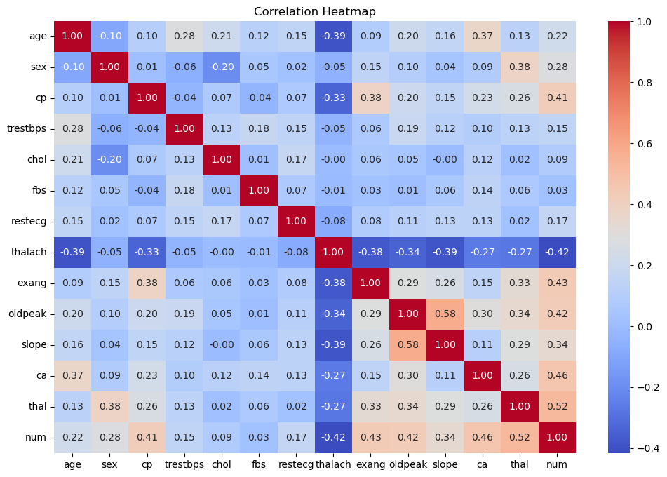

```python
plt.figure(figsize=(12,8))
sns.heatmap(df.corr(),annot=True,cmap="coolwarm",fmt=".2f")
plt.title("Correlation Heatmap")
plt.savefig("correlation_heatmap.png", dpi=300, bbox_inches="tight")
plt.show()
```

## 5.10 Outlier Detection

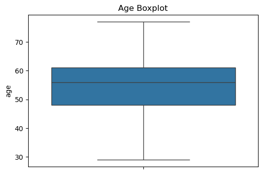

```python
plt.figure(figsize=(6,4))
sns.boxplot(y=df["age"])
plt.title("Age Boxplot")
plt.show()
```

### Resting Blood Pressure Boxplot

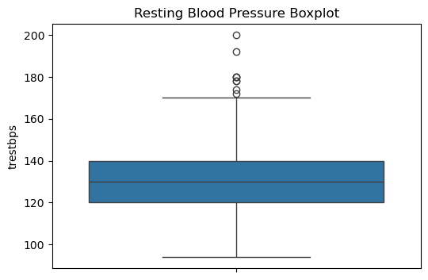

```python
plt.figure(figsize=(6,4))
sns.boxplot(y=df["trestbps"])
plt.title("Resting Blood Pressure Boxplot")
plt.show()
```

### Cholesterol Boxplot

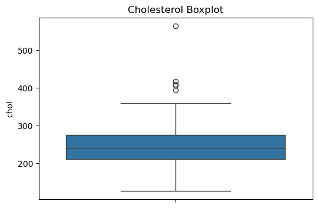

```python
plt.figure(figsize=(6,4))
sns.boxplot(y=df["chol"])
plt.title("Cholesterol Boxplot")
plt.show()
```

### Maximum Heart Rate Boxplot

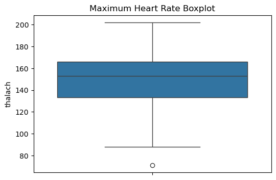

```python
plt.figure(figsize=(6,4))
sns.boxplot(y=df["thalach"])
plt.title("Maximum Heart Rate Boxplot")
plt.show()
```

### ST Depression (Oldpeak) Boxplot

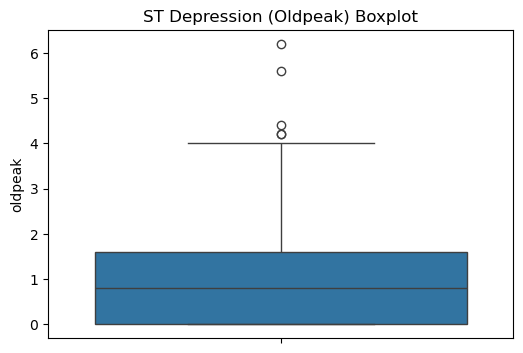

```python
plt.figure(figsize=(6,4))
sns.boxplot(y=df["oldpeak"])
plt.title("ST Depression (Oldpeak) Boxplot")
plt.show()
```

## 5.10 Relationship Analysis

### Gender vs Heart Disease

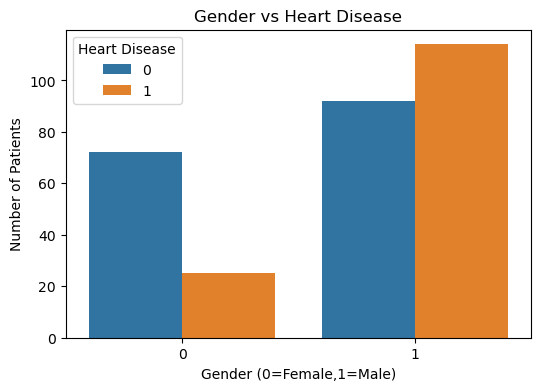

```python
plt.figure(figsize=(6,4))
sns.countplot(x="sex",hue="num",data=df)
plt.title("Gender vs Heart Disease")
plt.xlabel("Gender (0=Female,1=Male)")
plt.ylabel("Number of Patients")
plt.legend(title="Heart Disease")
plt.show()
```

### Chest Pain Type vs Heart Disease

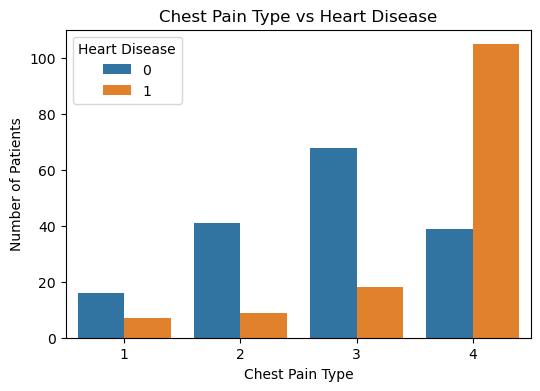

```python
plt.figure(figsize=(6,4))
sns.countplot(x="cp",hue="num",data=df)
plt.title("Chest Pain Type vs Heart Disease")
plt.xlabel("Chest Pain Type")
plt.ylabel("Number of Patients")
plt.legend(title="Heart Disease")
plt.show()
```

### Age vs Heart Disease

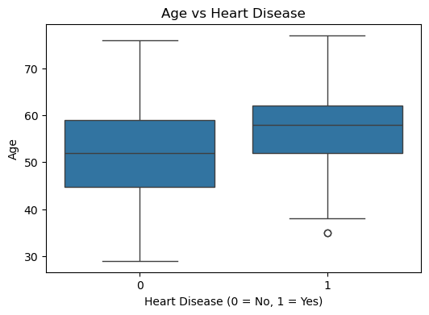

```python
plt.figure(figsize=(6,4))
sns.boxplot(x="num",y="age",data=df)
plt.title("Age vs Heart Disease")
plt.xlabel("Heart Disease (0 = No, 1 = Yes)")
plt.ylabel("Age")
plt.show()
```

## EDA Summary

The exploratory data analysis provided important insights into the dataset. Most patients belonged to the middle-aged group, and male patients were more common than female patients. The target variable showed a reasonably balanced distribution. Correlation analysis indicated that some features had stronger relationships with heart disease, while many features were only weakly correlated with each other. These observations helped in understanding the dataset before building machine learning models.

# 6. Feature Engineering

The dataset is already well-structured and does not require additional feature engineering. Existing features are directly used for model building.

# 7. Define Features and Target Variable

```python
X=df.drop("num",axis=1)
y=df["num"]
```

# 8. Train-Test Split

The dataset is divided into training and testing sets. The training set is used to train the machine learning models, while the testing set is used to evaluate their performance on unseen data.

```python
X_train,X_test,y_train,y_test=train_test_split(X,y,test_size=0.20,random_state=42)
```

```python
print("Training Set:",X_train.shape)
print("Testing Set :",X_test.shape)
```

```
Training Set: (242, 13)
Testing Set : (61, 13)
```

# 9. Feature Scaling

Feature scaling standardizes the numerical features so that they have a similar scale. This helps distance-based and gradient-based machine learning algorithms perform better.

```python
scaler=StandardScaler()
```

```python
X_train=scaler.fit_transform(X_train)
```

```python
X_test=scaler.transform(X_test)
```

# 10. Model Building

## 10.1 Logistic Regression

Logistic Regression is used as the baseline classification model because the target variable contains two classes (Heart Disease: Yes or No). It provides a simple and interpretable benchmark for comparing the performance of other machine learning models.

```python
lr_model=LogisticRegression(max_iter=1000,random_state=42)
```

### Train the Model

```python
lr_model.fit(X_train,y_train)
```

```
LogisticRegression(max_iter=1000, random_state=42)
```

### Make Predictions

```python
lr_pred=lr_model.predict(X_test)
```

### Training and Testing Accuracy

```python
print("Training Accuracy :",round(lr_model.score(X_train,y_train)*100,2),"%")
print("Testing Accuracy :",round(lr_model.score(X_test,y_test)*100,2),"%")
```

```
Training Accuracy : 84.3 %
Testing Accuracy : 88.52 %
```

## 10.2 Decision Tree

Decision Tree is trained to capture non-linear relationships between the input features and the target variable. It helps compare the performance of a tree-based model with Logistic Regression.

```python
dt_model=DecisionTreeClassifier(random_state=42)
```

### Train the Model

```python
dt_model.fit(X_train,y_train)
```

```
DecisionTreeClassifier(random_state=42)
```

### Make Predictions

```python
dt_pred=dt_model.predict(X_test)
```

### Training and Testing Accuracy

```python
print("Training Accuracy :",round(dt_model.score(X_train,y_train)*100,2),"%")
print("Testing Accuracy :",round(dt_model.score(X_test,y_test)*100,2),"%")
```

```
Training Accuracy : 100.0 %
Testing Accuracy : 75.41 %
```

## 10.3 Random Forest

Random Forest combines multiple Decision Trees to improve prediction accuracy and reduce overfitting. It is evaluated to determine whether an ensemble model performs better than individual models.

```python
rf_model=RandomForestClassifier(random_state=42)
```

### Train the Model

```python
rf_model.fit(X_train,y_train)
```

```
RandomForestClassifier(random_state=42)
```

### Make Predictions

```python
rf_pred=rf_model.predict(X_test)
```

### Training and Testing Accuracy

```python
print("Training Accuracy :", round(rf_model.score(X_train,y_train)*100,2),"%")
print("Testing Accuracy :", round(rf_model.score(X_test,y_test)*100,2),"%")
```

```
Training Accuracy : 100.0 %
Testing Accuracy : 86.89 %
```

# 11. Model Evaluation

## 11.1 Logistic Regression Evaluation

### Confusion Matrix

```python
cm_lr=confusion_matrix(y_test,lr_pred)
```

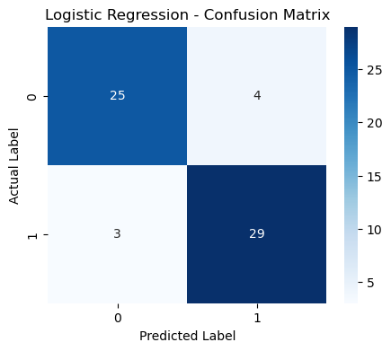

```python
plt.figure(figsize=(5,4))
sns.heatmap(cm_lr,annot=True,fmt="d",cmap="Blues")
plt.title("Logistic Regression - Confusion Matrix")
plt.xlabel("Predicted Label")
plt.ylabel("Actual Label")
plt.show()
```

### Classification Report

```python
print(classification_report(y_test,lr_pred))
```

```
              precision    recall  f1-score   support

           0       0.89      0.86      0.88        29
           1       0.88      0.91      0.89        32

    accuracy                           0.89        61
   macro avg       0.89      0.88      0.88        61
weighted avg       0.89      0.89      0.89        61
```

### ROC Curve

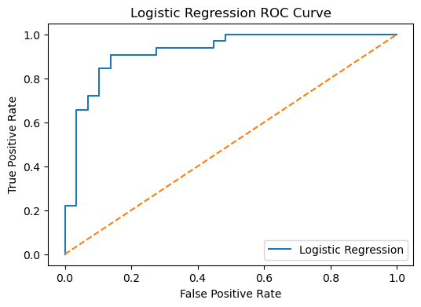

```python
lr_prob=lr_model.predict_proba(X_test)[:,1]
fpr,tpr,thresholds=roc_curve(y_test,lr_prob)
plt.figure(figsize=(6,4))
plt.plot(fpr,tpr,label="Logistic Regression")
plt.plot([0,1],[0,1],"--")
plt.xlabel("False Positive Rate")
plt.ylabel("True Positive Rate")
plt.title("Logistic Regression ROC Curve")
plt.legend()
plt.savefig("roc_curve.png", dpi=300, bbox_inches="tight")
plt.show()
```

### AUC Score

```python
lr_auc=roc_auc_score(y_test,lr_prob)
print("AUC Score :",round(lr_auc,3))
```

```
AUC Score : 0.921
```

## 11.2 Decision Tree Evaluation

### Confusion Matrix

```python
cm_dt=confusion_matrix(y_test,dt_pred)
```

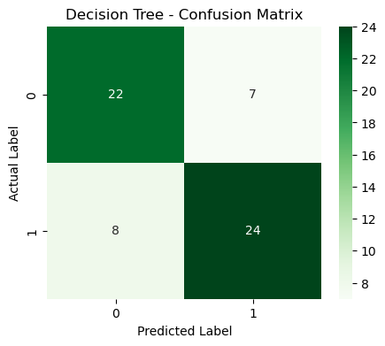

```python
plt.figure(figsize=(5,4))
sns.heatmap(cm_dt,annot=True,fmt="d",cmap="Greens")
plt.title("Decision Tree - Confusion Matrix")
plt.xlabel("Predicted Label")
plt.ylabel("Actual Label")
plt.show()
```

### Classification Report

```python
print(classification_report(y_test,dt_pred))
```

```
              precision    recall  f1-score   support

           0       0.73      0.76      0.75        29
           1       0.77      0.75      0.76        32

    accuracy                           0.75        61
   macro avg       0.75      0.75      0.75        61
weighted avg       0.75      0.75      0.75        61
```

### ROC Curve

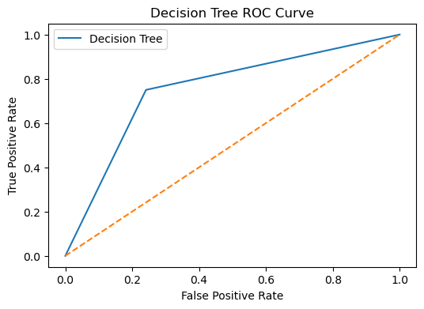

```python
dt_prob=dt_model.predict_proba(X_test)[:,1]
fpr_dt,tpr_dt,thresholds=roc_curve(y_test,dt_prob)
plt.figure(figsize=(6,4))
plt.plot(fpr_dt,tpr_dt,label="Decision Tree")
plt.plot([0,1],[0,1],"--")
plt.title("Decision Tree ROC Curve")
plt.xlabel("False Positive Rate")
plt.ylabel("True Positive Rate")
plt.legend()
plt.show()
```

### AUC Score

```python
dt_auc=roc_auc_score(y_test,dt_prob)
print("AUC Score :",round(dt_auc,3))
```

```
AUC Score : 0.754
```

## 11.3 Random Forest Evaluation

### Confusion Matrix

```python
cm_rf=confusion_matrix(y_test,rf_pred)
```

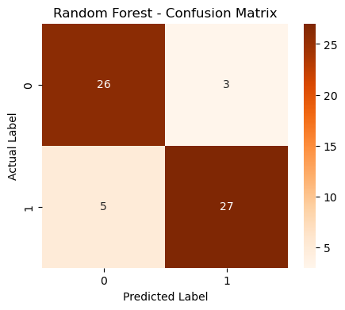

```python
plt.figure(figsize=(5,4))
sns.heatmap(cm_rf,annot=True,fmt="d",cmap="Oranges")
plt.title("Random Forest - Confusion Matrix")
plt.xlabel("Predicted Label")
plt.ylabel("Actual Label")
plt.show()
```

### Classification Report

```python
print(classification_report(y_test,rf_pred))
```

```
              precision    recall  f1-score   support

           0       0.84      0.90      0.87        29
           1       0.90      0.84      0.87        32

    accuracy                           0.87        61
   macro avg       0.87      0.87      0.87        61
weighted avg       0.87      0.87      0.87        61
```

### ROC Curve

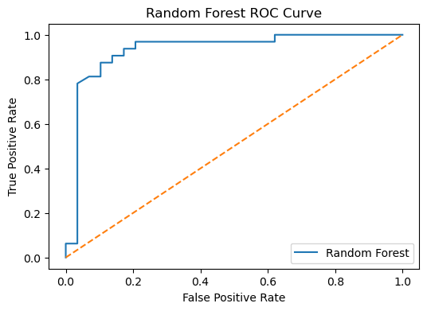

```python
rf_prob=rf_model.predict_proba(X_test)[:,1]
fpr_rf,tpr_rf,thresholds=roc_curve(y_test,rf_prob)
plt.figure(figsize=(6,4))
plt.plot(fpr_rf,tpr_rf,label="Random Forest")
plt.plot([0,1],[0,1],"--")
plt.title("Random Forest ROC Curve")
plt.xlabel("False Positive Rate")
plt.ylabel("True Positive Rate")
plt.legend()
plt.show()
```

### AUC Score

```python
rf_auc=roc_auc_score(y_test,rf_prob)
print("AUC Score :",round(rf_auc,3))
```

```
AUC Score : 0.932
```

# 12. Hyperparameter Tuning

GridSearchCV is used to identify the best combination of Decision Tree hyperparameters by performing cross-validation on multiple parameter values. This helps improve the model's generalization performance.

## 12.1 Define Parameter Grid

```python
param_grid={
    "criterion": ["gini", "entropy"],
    "max_depth": [3,5,7,None],
    "min_samples_split": [2,5,10],
    "min_samples_leaf": [1,2,4]
}
```

## 12.2 GridSearchCV

```python
grid_search= GridSearchCV(estimator=dt_model,param_grid=param_grid,cv=5,scoring="accuracy",n_jobs=-1)
```

## 12.3 Train GridSearchCV

```python
grid_search.fit(X_train,y_train)
```

```
GridSearchCV(cv=5, estimator=DecisionTreeClassifier(random_state=42), n_jobs=-1,
             param_grid={'criterion': ['gini', 'entropy'],
                         'max_depth': [3, 5, 7, None],
                         'min_samples_leaf': [1, 2, 4],
                         'min_samples_split': [2, 5, 10]},
             scoring='accuracy')
```

## 12.4 Best Parameters

```python
print("Best Parameters:")
print(grid_search.best_params_)
```

```
Best Parameters:
{'criterion': 'entropy', 'max_depth': 5, 'min_samples_leaf': 2, 'min_samples_split': 5}
```

## 12.5 Best Cross Validation Score

```python
print("Best Cross Validation Score:")
print(round(grid_search.best_score_,3))
```

```
Best Cross Validation Score:
0.773
```

## 12.6 Best Tuned Decision Tree

```python
best_dt_model=grid_search.best_estimator_
```

## 12.7 Prediction Using Tuned Model

```python
best_dt_pred=best_dt_model.predict(X_test)
```

## 12.8 Tuned Decision Tree Accuracy

```python
print("Training Accuracy :",round(best_dt_model.score(X_train,y_train)*100,2),"%")
print("Testing Accuracy :",round(best_dt_model.score(X_test,y_test)*100,2),"%")
```

```
Training Accuracy : 91.74 %
Testing Accuracy : 75.41 %
```

# 13. Feature Importance

## Decision Tree Feature Importance

```python
feature_importance=pd.DataFrame({
    "Feature":X.columns,
    "Importance":best_dt_model.feature_importances_
})
```

```python
feature_importance=feature_importance.sort_values(by="Importance",ascending=False)
```

```python
feature_importance
```

|  | Feature | Importance |
| --- | --- | --- |
| 2 | cp | 0.245316 |
| 11 | ca | 0.171277 |
| 0 | age | 0.157691 |
| 4 | chol | 0.145206 |
| 12 | thal | 0.111056 |
| 9 | oldpeak | 0.078008 |
| 1 | sex | 0.046912 |
| 7 | thalach | 0.025687 |
| 8 | exang | 0.018847 |
| 3 | trestbps | 0.000000 |
| 6 | restecg | 0.000000 |
| 5 | fbs | 0.000000 |
| 10 | slope | 0.000000 |

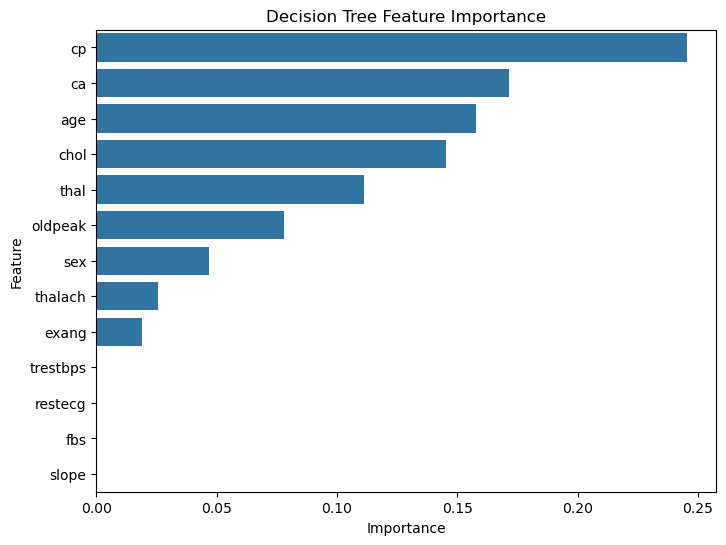

```python
plt.figure(figsize=(8,6))
sns.barplot(data=feature_importance,x="Importance",y="Feature")
plt.title("Decision Tree Feature Importance")
plt.savefig("feature_importance.png", dpi=300, bbox_inches="tight")
plt.show()
```

# 14. Cross Validation

Cross Validation evaluates the model on multiple train-test splits to estimate how well it generalizes to unseen data. It provides a more reliable performance estimate than a single train-test split.

```python
lr_cv=LogisticRegression(max_iter=5000,random_state=42)
cv_scores=cross_val_score(lr_cv,X,y,cv=5,scoring="accuracy")
```

```python
print("Cross Validation Scores:",cv_scores)
print("Average Cross Validation Accuracy:",round(cv_scores.mean()*100,2),"%")
```

```
Cross Validation Scores: [0.83606557 0.86885246 0.78688525 0.81666667 0.8       ]
Average Cross Validation Accuracy: 82.17 %
```

# 15. Model Comparison

## Accuracy Comparison

```python
comparison=pd.DataFrame({
    "Model":[
        "Logistic Regression",
        "Decision Tree",
        "Random Forest"
    ],
    "Training Accuracy":[
        round(lr_model.score(X_train,y_train)*100,2),
        round(dt_model.score(X_train,y_train)*100,2),
        round(rf_model.score(X_train,y_train)*100,2)
    ],
    "Testing Accuracy":[
        round(lr_model.score(X_test,y_test)*100,2),
        round(dt_model.score(X_test,y_test)*100,2),
        round(rf_model.score(X_test,y_test)*100,2)
    ]
})
comparison
```

|  | Model | Training Accuracy | Testing Accuracy |
| --- | --- | --- | --- |
| 0 | Logistic Regression | 84.3 | 88.52 |
| 1 | Decision Tree | 100.0 | 75.41 |
| 2 | Random Forest | 100.0 | 86.89 |

### Accuracy Comparison Chart

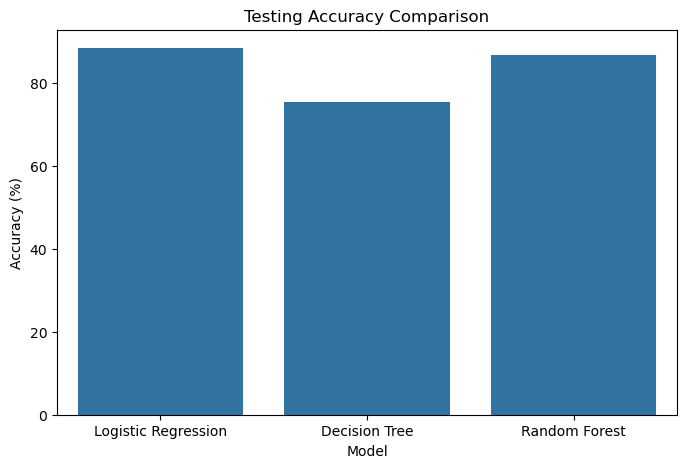

```python
plt.figure(figsize=(8,5))
sns.barplot(data=comparison,x="Model",y="Testing Accuracy")
plt.title("Testing Accuracy Comparison")
plt.ylabel("Accuracy (%)")
plt.savefig("model_comparison.png", dpi=300, bbox_inches="tight")
plt.show()
```

## Best Model Selection

```python
best_model=comparison.loc[comparison["Testing Accuracy"].idxmax()]
best_model
```

```
Model                Logistic Regression
Training Accuracy                   84.3
Testing Accuracy                   88.52
Name: 0, dtype: object
```

```python
print("Best Model :",best_model["Model"])
print("Testing Accuracy :",best_model["Testing Accuracy"],"%")
```

```
Best Model : Logistic Regression
Testing Accuracy : 88.52 %
```

# 16. Save and Load Best Model

## Save Best Model

```python
joblib.dump(lr_model,"heart_disease_model.pkl")
```

```
['heart_disease_model.pkl']
```

## Load Saved Model

```python
loaded_model=joblib.load("heart_disease_model.pkl")
```

# 17. New Patient Prediction

## New Patient Data

```python
new_patient=[[55,1,2,140,250,0,1,150,0,1.5,2,0,2]]
```

## Prediction

```python
prediction=loaded_model.predict(new_patient)
```

## Result

```python
if prediction[0]==0:
    print("Prediction : No Heart Disease")
else:
    print("Prediction : Heart Disease")
```

```
Prediction : Heart Disease
```

# 18. Conclusion

This project developed a machine learning model to predict the presence of heart disease using patient clinical data.

Three classification algorithms were evaluated:

- Logistic Regression
- Decision Tree
- Random Forest

Among these models, Logistic Regression achieved the best testing accuracy (88.52%) and demonstrated stable performance without overfitting. Decision Tree showed clear signs of overfitting, while Random Forest performed well but slightly lower than Logistic Regression on the testing data.

This project demonstrates a complete machine learning workflow including data preprocessing, exploratory data analysis, feature scaling, model building, evaluation, hyperparameter tuning, cross-validation, feature importance analysis, and model comparison.

## Future Improvements

- Train the model on a larger dataset.
- Perform advanced hyperparameter tuning.
- Try additional machine learning algorithms such as XGBoost and Support Vector Machine.
- Deploy the trained model as a web application using Streamlit or Flask.